Дальше будут попытки finenuting'а нескольких моделей, чтобы их как-то можно было бы сравнить между собой, сразу разделим текст на train и test

# 3_0_make_cross_dataset

```python
import pandas as pd
from datasets import Dataset
```

```python
df = pd.read_parquet('./__input__/mathced.parquet')

df
```

|  | nmId | text | responder | type | product_name | product_category_2 | product_category_1 | product_color | product_description | product_brand | ... | target_type | target_product_name | target_product_category_2 | target_product_category_1 | target_product_color | target_product_description | target_product_brand | target_vector | target_toxicity | target_emotions |
| --- | --- | --- | --- | --- | --- | --- | --- | --- | --- | --- | --- | --- | --- | --- | --- | --- | --- | --- | --- | --- | --- |
| 0 | 7728617 | ДОБРОГО ВРЕМЕНИ СУТОК! БУДЬТЕ ДОБРЫ, ПОДСКАЖИТ... | Клиент | Вопрос | Футболка | Футболки | Одежда | белый |  | Gulliver | ... | Вопрос | Брюки для девочек чиносы в клетку | Брюки | Одежда | черный, серый | Лето – пора обновить свой гардероб стильными и... | Fart Favorita | [0.13500252, 0.1903846, -0.00873054, -0.123853... | non-toxic | no_emotion |
| 1 | 8359265 | Пишу повторный отзыв, проработал в итоге не бо... | Клиент | Отзыв | Светильник настольный аккумуляторный | Светильники | Дом | черный | Светильние настольный Ultraflash предназначен ... | Ultraflash | ... | Отзыв | Penguin вибратор стимулятор клитора | Вакуумно-волновые стимуляторы | Товары для взрослых | черный | Стильный вибратор Satisfyer Penguin изготовлен... | Satisfyer | [-0.15306002, 0.07590134, 0.015008428, -0.0214... | non-toxic | joy |
| 2 | 3081307 | цвет темнее чем на фото. чашечка одна была зал... | Клиент | Отзыв | Купальник | Раздельные купальники | Белье | синий | Формованная чашка с гелевым пуш-апом на каркас... | FIANETA | ... | Отзыв | Бюстгальтер формованный | Бюстгальтеры | Белье | белый |  | Orhideja | [0.068778165, 0.08620114, -0.19951291, 0.19610... | non-toxic | no_emotion |
| 3 | 6144081 | В нее можно дуть,как в дудку,или это просто по... | Клиент | Вопрос | Погремушка Горн | Погремушки | Игрушки | зеленый | Погремушка в форме горна из пластмассы. Звук с... | Bampi | ... | Вопрос | Тушь для ресниц TRIUMPH Black&White Show Masca... | Туши | Красота | коричневый | Трехмерный объем, разделение, удлинение и крас... | TF | [0.08773147, -0.06438803, 0.14793167, 0.032130... | non-toxic | no_emotion |
| 4 | 88636591 | Ужасные стекла ,брал на Poco X 3, не достаёт п... | Клиент | Отзыв | Защитное стекло для Poco X3/ X3 Pro/ F3 | Защитные стекла | Смартфоны и аксессуары | прозрачный | На все наши стекла распространяктся 40-дневная... | POCO | ... | Отзыв | Cтекло Поко Poco X3, X3 NFC, X3 Pro, F3, X4 pr... | Защитные стекла | Смартфоны и аксессуары |  | Защитное стекло Poco X3, Poco X3 Pro, Poco X3 ... | Frugly | [-0.12641513, 0.024109557, 0.30289555, 0.00659... | non-toxic | no_emotion |
| ... | ... | ... | ... | ... | ... | ... | ... | ... | ... | ... | ... | ... | ... | ... | ... | ... | ... | ... | ... | ... | ... |
| 22378 | 8172469 | Добрый день! Длина 36см, ширина по талии 36см | Магазин | Вопрос | Юбка | Юбки | Одежда | синий | Юбка из расшитого хлопка, со сборкой по талии,... | ACOOLA | ... | Вопрос | Юбка | Юбки | Одежда | синий | Юбка из расшитого хлопка, со сборкой по талии,... | ACOOLA | [0.28716046, 0.2006678, 0.016394911, -0.042199... | non-toxic | joy |
| 22379 | 2561778 | Как мне оформить отказ от заказа под номером.1... | Клиент | Вопрос | Карандаш для губ Lasting Finish 1000 Kisses, т... | Косметические карандаши | Красота | темно-бежевый |  | Rimmel | ... | Вопрос | Карандаш для губ Lasting Finish 1000 Kisses, т... | Косметические карандаши | Красота | темно-бежевый |  | Rimmel | [-0.13532826, 0.13940834, -0.16434129, 0.00734... | non-toxic | no_emotion |
| 22380 | 10416573 | Внешне смотрятся хорошо. Удобные - на широкую ... | Клиент | Отзыв | Ботинки зимние/ натуральный мех | Ботинки | Обувь | синий | Бренд ZILFILD производит обувь ручной работы т... | ZILFILD | ... | Отзыв | Ботинки зимние/ натуральный мех | Ботинки | Обувь | синий | Бренд ZILFILD производит обувь ручной работы т... | ZILFILD | [0.2490824, 0.30120248, -0.16389012, 0.0481176... | non-toxic | no_emotion |
| 22381 | 3705090 | Здравствуйте! Костюм голубой-оранжевый пришел ... | Клиент | Вопрос | Костюм женский спортивный с начесом больших ра... | Костюмы спортивные | Спортивная одежда | серый | Костюм спортивный женский с начесом выполнен и... | Алтекс. | ... | Вопрос | Костюм женский спортивный с начесом больших ра... | Костюмы спортивные | Спортивная одежда | серый | Костюм спортивный женский с начесом выполнен и... | Алтекс. | [0.117600515, 0.3701609, 0.097081475, 0.160216... | non-toxic | joy |
| 22382 | 3256894 | Здравствуйте. Лампочка не гаснет. Заряжать маш... | Магазин | Вопрос | Машинка для стрижки волос ER131H520 | Машинки для стрижки волос | Бытовая техника | белый, серый | Электрическая машинка для стрижки волос, может... | Panasonic | ... | Вопрос | Машинка для стрижки волос ER131H520 | Машинки для стрижки волос | Бытовая техника | белый, серый | Электрическая машинка для стрижки волос, может... | Panasonic | [-0.09474845, 0.122863844, 0.25407657, 0.27802... | non-toxic | no_emotion |

22383 rows × 26 columns

```python
df[df['text'] == df['target_text']]
```

|  | nmId | text | responder | type | product_name | product_category_2 | product_category_1 | product_color | product_description | product_brand | ... | target_type | target_product_name | target_product_category_2 | target_product_category_1 | target_product_color | target_product_description | target_product_brand | target_vector | target_toxicity | target_emotions |
| --- | --- | --- | --- | --- | --- | --- | --- | --- | --- | --- | --- | --- | --- | --- | --- | --- | --- | --- | --- | --- | --- |
| 16830 | 2558794 | Здравствуйте! Имеет ли изделие алмазную огранку? | Клиент | Вопрос | Цепочка | Ювелирные цепочки | Ювелирные украшения | золотистый | Цепочка из золота 585 пробы. Значение веса на ... | Бронницкий ювелир | ... | Вопрос | Цепочка | Ювелирные цепочки | Ювелирные украшения | золотистый | Цепочка из золота 585 пробы. Значение веса на ... | Бронницкий ювелир | [0.01924289, 0.285982, 0.028851524, -0.0684657... | non-toxic | surprise |
| 16831 | 6536986 | Здравствуйте.подскажите есть ли у вас духи по ... | Клиент | Вопрос | ISLAND Туалетная вода Айленд муж | Туалетная вода | Красота |  | Семейство: пряные, древесныеНота головы: грейп... | BI-ES | ... | Вопрос | ISLAND Туалетная вода Айленд муж | Туалетная вода | Красота |  | Семейство: пряные, древесныеНота головы: грейп... | BI-ES | [0.08186785, 0.18698356, 0.0136558805, -0.0488... | non-toxic | no_emotion |
| 16832 | 7649269 | Будут ли ещё фотографии часов с разных ракурсов? | Клиент | Вопрос | Наручные часы PG255ES3-43A | Часы наручные | Аксессуары | синий | Мужские наручные часы Philip Laurence PG255ES3... | Philip Laurence | ... | Вопрос | Наручные часы PG255ES3-43A | Часы наручные | Аксессуары | синий | Мужские наручные часы Philip Laurence PG255ES3... | Philip Laurence | [0.031470247, 0.0012439148, 0.15464528, 0.1156... | non-toxic | no_emotion |
| 16833 | 18577305 | Клей слабенький, но подойдёт для декупажа, раб... | Клиент | Отзыв | Клей ПВА универсальный для бумаги, обоев, лино... | Клей строительный | Строительные материалы |  | Клей ПВА универсальный Professional применяетс... | PROFESSIONAL | ... | Отзыв | Клей ПВА универсальный для бумаги, обоев, лино... | Клей строительный | Строительные материалы |  | Клей ПВА универсальный Professional применяетс... | PROFESSIONAL | [-0.072557464, 0.15734829, 0.24484612, 0.08203... | non-toxic | no_emotion |
| 16834 | 14551833 | Добрый день! Очень рады, что Вы остались довол... | Магазин | Отзыв | Комбинезон-трансформер ROSES со вставкой из ов... | Комбинезоны для малышей | Одежда для малышей | бордовый, розовый | Комбинезон украшен цветочным принтом и оригина... | PILGUNI. | ... | Отзыв | Комбинезон-трансформер ROSES со вставкой из ов... | Комбинезоны для малышей | Одежда для малышей | бордовый, розовый | Комбинезон украшен цветочным принтом и оригина... | PILGUNI. | [0.16040404, 0.09267748, 0.05264257, -0.128110... | non-toxic | joy |
| ... | ... | ... | ... | ... | ... | ... | ... | ... | ... | ... | ... | ... | ... | ... | ... | ... | ... | ... | ... | ... | ... |
| 22378 | 8172469 | Добрый день! Длина 36см, ширина по талии 36см | Магазин | Вопрос | Юбка | Юбки | Одежда | синий | Юбка из расшитого хлопка, со сборкой по талии,... | ACOOLA | ... | Вопрос | Юбка | Юбки | Одежда | синий | Юбка из расшитого хлопка, со сборкой по талии,... | ACOOLA | [0.28716046, 0.2006678, 0.016394911, -0.042199... | non-toxic | joy |
| 22379 | 2561778 | Как мне оформить отказ от заказа под номером.1... | Клиент | Вопрос | Карандаш для губ Lasting Finish 1000 Kisses, т... | Косметические карандаши | Красота | темно-бежевый |  | Rimmel | ... | Вопрос | Карандаш для губ Lasting Finish 1000 Kisses, т... | Косметические карандаши | Красота | темно-бежевый |  | Rimmel | [-0.13532826, 0.13940834, -0.16434129, 0.00734... | non-toxic | no_emotion |
| 22380 | 10416573 | Внешне смотрятся хорошо. Удобные - на широкую ... | Клиент | Отзыв | Ботинки зимние/ натуральный мех | Ботинки | Обувь | синий | Бренд ZILFILD производит обувь ручной работы т... | ZILFILD | ... | Отзыв | Ботинки зимние/ натуральный мех | Ботинки | Обувь | синий | Бренд ZILFILD производит обувь ручной работы т... | ZILFILD | [0.2490824, 0.30120248, -0.16389012, 0.0481176... | non-toxic | no_emotion |
| 22381 | 3705090 | Здравствуйте! Костюм голубой-оранжевый пришел ... | Клиент | Вопрос | Костюм женский спортивный с начесом больших ра... | Костюмы спортивные | Спортивная одежда | серый | Костюм спортивный женский с начесом выполнен и... | Алтекс. | ... | Вопрос | Костюм женский спортивный с начесом больших ра... | Костюмы спортивные | Спортивная одежда | серый | Костюм спортивный женский с начесом выполнен и... | Алтекс. | [0.117600515, 0.3701609, 0.097081475, 0.160216... | non-toxic | joy |
| 22382 | 3256894 | Здравствуйте. Лампочка не гаснет. Заряжать маш... | Магазин | Вопрос | Машинка для стрижки волос ER131H520 | Машинки для стрижки волос | Бытовая техника | белый, серый | Электрическая машинка для стрижки волос, может... | Panasonic | ... | Вопрос | Машинка для стрижки волос ER131H520 | Машинки для стрижки волос | Бытовая техника | белый, серый | Электрическая машинка для стрижки волос, может... | Panasonic | [-0.09474845, 0.122863844, 0.25407657, 0.27802... | non-toxic | no_emotion |

5553 rows × 26 columns

После проверки работы модели в ноубуке 3_5_main_model, было замечано, что из-за повторяюшихся в таргете и инпуте текстах, модель переобучается и начинает просто копировать текст из поля text

```python
df = df[df['text'] != df['target_text']]
```

```python
ds = Dataset.from_pandas(df)
ds = ds.train_test_split(test_size=0.1) # type: ignore

ds
```

```
DatasetDict({
    train: Dataset({
        features: ['nmId', 'text', 'responder', 'type', 'product_name', 'product_category_2', 'product_category_1', 'product_color', 'product_description', 'product_brand', 'vector', 'toxicity', 'emotions', 'target_nmId', 'target_text', 'target_responder', 'target_type', 'target_product_name', 'targ…
        num_rows: 15147
    })
    test: Dataset({
        features: ['nmId', 'text', 'responder', 'type', 'product_name', 'product_category_2', 'product_category_1', 'product_color', 'product_description', 'product_brand', 'vector', 'toxicity', 'emotions', 'target_nmId', 'target_text', 'target_responder', 'target_type', 'target_product_name', 'targ…
        num_rows: 1683
    })
})
```

```python
ds['train'].to_parquet('./__output__/matched_train.parquet') # type: ignore
ds['test'].to_parquet('./__output__/matched_test.parquet') # type: ignore
```

```
11693410
```

*Из-за низкой скорости обработки одного батча (в перещете на один текст присерно 10 сек.), код этого и последующих этапов делался в облаке на Tesla A10

Так же все ноутбуки из 3 группы, в общем, одинаковы и содержат лишь изменеия, необходимые для обучения модели указанной в названии

# 3_1_t5_model

```python
import torch
import uuid
import os
import evaluate
from datasets import Dataset
from transformers import (
    T5ForConditionalGeneration,
    AutoTokenizer,
    DataCollatorForSeq2Seq,
    Seq2SeqTrainer,
    Seq2SeqTrainingArguments
)
from peft import LoraConfig, get_peft_model, TaskType # type: ignore
from tqdm import tqdm
```

Из-за того, что мы создаем датасет с помощью матчинга негативных текстов в какой-либо текст из позитивной или нейтральной группы, неизбежно появляются ошибки связанные с тем, что в оригинальном тексте и таргете, может в принципе говориться про разные продукты.

Чтобы хоть как-то передать информацию о желаемым результатом, я предлагаю включить в промт информацию о продукте и типу текста

```python
train = Dataset.from_parquet('./__output__/matched_train.parquet')
test = Dataset.from_parquet('./__output__/matched_test.parquet')
```

```
Generating train split: 0 examples [00:00, ? examples/s]
```

```
Generating train split: 0 examples [00:00, ? examples/s]
```

```python
train
```

```
Dataset({
    features: ['nmId', 'text', 'responder', 'type', 'product_name', 'product_category_2', 'product_category_1', 'product_color', 'product_description', 'product_brand', 'vector', 'toxicity', 'emotions', 'target_nmId', 'target_text', 'target_responder', 'target_type', 'target_product_name', 'target_p…
    num_rows: 15147
})
```

```python
test
```

```
Dataset({
    features: ['nmId', 'text', 'responder', 'type', 'product_name', 'product_category_2', 'product_category_1', 'product_color', 'product_description', 'product_brand', 'vector', 'toxicity', 'emotions', 'target_nmId', 'target_text', 'target_responder', 'target_type', 'target_product_name', 'target_p…
    num_rows: 1683
})
```

Так как у нас задача Seq2Seq модель, самым логичным вариантом будет выбрать какую-либо Encoder-Decoder модель, из которых самая популярная это flan-t5

```python
model = T5ForConditionalGeneration.from_pretrained(
    'google/flan-t5-small',
    device_map='cuda:0',
    torch_dtype=torch.bfloat16,
)
tokenizer = AutoTokenizer.from_pretrained(
    'google/flan-t5-small',
    useFast=True
)

coll = DataCollatorForSeq2Seq(model=model, tokenizer=tokenizer)
```

Чтобы не обучать модель end-to-end, тратя огромное количество времени и видеопамяти, буду обучать Lora Адаптер к весам модели

```python
sum([p.numel() for p in model.parameters() if p.requires_grad])
```

```
76961152
```

```python
peft_conf = LoraConfig(
    TaskType.SEQ_2_SEQ_LM,
    r=32,
    lora_alpha=32,
    target_modules=['q', 'v'],
    lora_dropout=0.1,
    bias='none',
    inference_mode=False
)

peft_model = get_peft_model(model, peft_conf)
```

```python
sum([p.numel() for p in peft_model.parameters() if p.requires_grad])
```

```
1376256
```

```python
max([len(tokenizer.tokenize(row['text'])) for row in train]) # type: ignore
```

```
Token indices sequence length is longer than the specified maximum sequence length for this model (589 > 512). Running this sequence through the model will result in indexing errors
```

```
931
```

```python
max([len(tokenizer.tokenize(row['target_text'])) for row in train]) # type: ignore
```

```
817
```

```python
def preprocess(e):
    out = tokenizer(
        f'''
responder: {e['target_responder']}
type: {e['target_type']}
product_name: {e['target_product_name']}
product_category_2: {e['target_product_category_2']}
product_color: {e['target_product_color']}
product_brand: {e['target_product_brand']}
product_description: {e['target_product_description']}
toxicity: {e['toxicity']}
emotions: {e['emotions']}
text: {e['text']}
        ''',
        truncation=True,
        max_length=1500,
        return_tensors='pt'
    )

    out['input_ids'] = out['input_ids'][0] # type: ignore
    out['attention_mask'] = out['attention_mask'][0] # type: ignore

    labels = tokenizer(
        text_target=e['target_text'],
        max_length=1500,
        truncation=True,
        return_tensors='pt'
    )
    out['labels'] = labels['input_ids'][0] # type: ignore

    return out
```

```python
train = train.map(preprocess, remove_columns=train.column_names) # type: ignore
test = test.map(preprocess, remove_columns=test.column_names) # type: ignore

train
```

```
Dataset({
    features: ['input_ids', 'attention_mask', 'labels'],
    num_rows: 15147
})
```

```python
checkpoint = str(uuid.uuid4())

checkpoint
```

```
'8fd9c01d-3ad4-4dcf-b00c-ccb399091a74'
```

```python
os.makedirs(f'./models/{checkpoint}')
```

```python
args = Seq2SeqTrainingArguments(
    output_dir=f'./models/{checkpoint}/runs',
    eval_strategy='epoch',
    per_device_train_batch_size=5,
    per_device_eval_batch_size=5,
    num_train_epochs=5,
    learning_rate=0.001,
    warmup_ratio=0.1,
    weight_decay=0.01,
    save_strategy='no',
    remove_unused_columns=False,
    bf16=True,
    predict_with_generate=True,
    generation_max_length=300
)

trainer = Seq2SeqTrainer(
    model=peft_model, # type: ignore
    args=args,
    data_collator=coll,
    train_dataset=train, # type: ignore
    eval_dataset=test, # type: ignore
)
```

```python
trainer.train()
```

```
Passing a tuple of `past_key_values` is deprecated and will be removed in Transformers v4.48.0. You should pass an instance of `EncoderDecoderCache` instead, e.g. `past_key_values=EncoderDecoderCache.from_legacy_cache(past_key_values)`.
```

[15150/15150 1:01:44, Epoch 5/5]

| Epoch | Training Loss | Validation Loss |
| --- | --- | --- |
| 1 | 2.101300 | 1.937135 |
| 2 | 2.017700 | 1.856336 |
| 3 | 1.968600 | 1.819550 |
| 4 | 1.930100 | 1.794183 |
| 5 | 1.933900 | 1.783127 |

```
TrainOutput(global_step=15150, training_loss=2.0216667089682603, metrics={'train_runtime': 3705.7868, 'train_samples_per_second': 20.437, 'train_steps_per_second': 4.088, 'total_flos': 3.591972182035661e+16, 'train_loss': 2.0216667089682603, 'epoch': 5.0})
```

```python
trainer.save_model(f'./models/{checkpoint}/model')
```

Из-за того, чтобы снять три основных NLP метрики, необходимо генерировать текст, для меня было невозможно снимать метрики на эпохах обучения. Ограничился лишь снятием метрик в конце обучения, из-за чего ничего не могу сказать про динамику метрик

Метрики:

- Meteor - позволяет оценить общее совпадение текста
- Bleu - позволяет сконцентрироваться на правильно угаданных n-gramm
- RougeLsum - позволяет сконцентрироваться на полноту унаданных n-gramm

```python
meteor = evaluate.load('evaluate-metric/meteor')
rouge = evaluate.load('evaluate-metric/rouge')
bleu = evaluate.load('evaluate-metric/bleu')
```

```python
targets = []
preds = []
for row in tqdm(test):
    text_input_ids = torch.LongTensor([row['input_ids']]).to('cuda:0')
    text_attention_mask = torch.LongTensor([row['attention_mask']]).to('cuda:0')

    model_out = model.generate(
        input_ids=text_input_ids,
        attention_mask=text_attention_mask,
        top_k=1,
        do_sample=True
    )[0]

    preds.append(tokenizer.decode(model_out, skip_special_tokens=True))
    targets.append(tokenizer.decode(row['labels'], skip_special_tokens=True))
```

```
  warnings.warn(
```

```python
print(f'''
Test metrice:
Meteor: {meteor.compute(predictions=preds, references=targets)['meteor']}
Rouge: {rouge.compute(predictions=preds, references=targets)['rougeLsum']},
Bleu: {bleu.compute(predictions=preds, references=targets)['bleu']}
''')
```

```
Test metrice:
Meteor: 0.06076279690497971
Rouge: 0.0030566091432843905,
Bleu: 5.0306628085742025e-06
```

# 3_2_rut5_model

Отличия от 3_5 минимальны, лишь изменил макимальную длинну токенизированного текста, так как из-за более хорошего токенизатора для русского языка, длинна токена у этой модели в среднем больше

```python
import torch
import uuid
import os
import evaluate
from datasets import Dataset
from transformers import (
    T5ForConditionalGeneration,
    AutoTokenizer,
    DataCollatorForSeq2Seq,
    Seq2SeqTrainer,
    Seq2SeqTrainingArguments
)
from peft import LoraConfig, get_peft_model, TaskType # type: ignore
from tqdm import tqdm
```

```python
train = Dataset.from_parquet('./__output__/matched_train.parquet')
test = Dataset.from_parquet('./__output__/matched_test.parquet')
```

```python
train
```

```
Dataset({
    features: ['nmId', 'text', 'responder', 'type', 'product_name', 'product_category_2', 'product_category_1', 'product_color', 'product_description', 'product_brand', 'vector', 'toxicity', 'emotions', 'target_nmId', 'target_text', 'target_responder', 'target_type', 'target_product_name', 'target_p…
    num_rows: 15147
})
```

```python
test
```

```
Dataset({
    features: ['nmId', 'text', 'responder', 'type', 'product_name', 'product_category_2', 'product_category_1', 'product_color', 'product_description', 'product_brand', 'vector', 'toxicity', 'emotions', 'target_nmId', 'target_text', 'target_responder', 'target_type', 'target_product_name', 'target_p…
    num_rows: 1683
})
```

```python
model = T5ForConditionalGeneration.from_pretrained(
    'ai-forever/ruT5-base',
    device_map='cuda:0',
    torch_dtype=torch.bfloat16,
)
tokenizer = AutoTokenizer.from_pretrained(
    'ai-forever/ruT5-base',
    useFast=True
)

coll = DataCollatorForSeq2Seq(model=model, tokenizer=tokenizer)
```

```
You are using the default legacy behaviour of the <class 'transformers.models.t5.tokenization_t5.T5Tokenizer'>. This is expected, and simply means that the `legacy` (previous) behavior will be used so nothing changes for you. If you want to use the new behaviour, set `legacy=False`. This should only…
```

```python
sum([p.numel() for p in model.parameters() if p.requires_grad])
```

```
222903552
```

```python
peft_conf = LoraConfig(
    TaskType.SEQ_2_SEQ_LM,
    r=16,
    lora_alpha=32,
    target_modules=['q', 'v'],
    lora_dropout=0.1,
    bias='none',
    inference_mode=False
)

peft_model = get_peft_model(model, peft_conf)
```

```python
sum([p.numel() for p in peft_model.parameters() if p.requires_grad])
```

```
1769472
```

```python
def preprocess(e):
    out = tokenizer(
        f'''
ответчик: {e['target_responder']}
тип: {e['target_type']}
название: {e['target_product_name']}
категория 2: {e['target_product_category_2']}
цвет: {e['target_product_color']}
бренд: {e['target_product_brand']}
описание: {e['target_product_description']}
токсичность: {e['toxicity']}
эиоциональность: {e['emotions']}
текст: {e['text']}
        ''',
        truncation=True,
        max_length=1400,
        return_tensors='pt'
    )

    out['input_ids'] = out['input_ids'][0] # type: ignore
    out['attention_mask'] = out['attention_mask'][0] # type: ignore

    labels = tokenizer(
        text_target=e['target_text'],
        max_length=1200,
        truncation=True,
        return_tensors='pt'
    )
    out['labels'] = labels['input_ids'][0] # type: ignore

    return out
```

```python
train = train.map(preprocess, remove_columns=train.column_names) # type: ignore
test = test.map(preprocess, remove_columns=test.column_names) # type: ignore

train
```

```
Dataset({
    features: ['input_ids', 'attention_mask', 'labels'],
    num_rows: 15147
})
```

```python
checkpoint = str(uuid.uuid4())

checkpoint
```

```
'25494ed9-f307-4293-a192-80678a7aca3a'
```

```python
os.makedirs(f'./models/{checkpoint}')
```

```python
args = Seq2SeqTrainingArguments(
    output_dir=f'./models/{checkpoint}/runs',
    eval_strategy='epoch',
    per_device_train_batch_size=5,
    per_device_eval_batch_size=5,
    num_train_epochs=5,
    learning_rate=0.001,
    warmup_ratio=0.1,
    weight_decay=0.01,
    save_strategy='no',
    remove_unused_columns=False,
    bf16=True
)

trainer = Seq2SeqTrainer(
    model=peft_model, # type: ignore
    args=args,
    data_collator=coll,
    train_dataset=train, # type: ignore
    eval_dataset=test, # type: ignore
)
```

```python
trainer.train()
```

```
Passing a tuple of `past_key_values` is deprecated and will be removed in Transformers v4.48.0. You should pass an instance of `EncoderDecoderCache` instead, e.g. `past_key_values=EncoderDecoderCache.from_legacy_cache(past_key_values)`.
```

[15150/15150 49:27, Epoch 5/5]

| Epoch | Training Loss | Validation Loss |
| --- | --- | --- |
| 1 | 4.154400 | 3.685551 |
| 2 | 3.974700 | 3.571082 |
| 3 | 3.878500 | 3.517082 |
| 4 | 3.793700 | 3.486148 |
| 5 | 3.760100 | 3.463229 |

```
TrainOutput(global_step=15150, training_loss=4.0155459000489895, metrics={'train_runtime': 2968.5451, 'train_samples_per_second': 25.512, 'train_steps_per_second': 5.104, 'total_flos': 4.788360886682419e+16, 'train_loss': 4.0155459000489895, 'epoch': 5.0})
```

```python
trainer.save_model(f'./models/{checkpoint}/model')
```

```python
meteor = evaluate.load('evaluate-metric/meteor')
rouge = evaluate.load('evaluate-metric/rouge')
bleu = evaluate.load('evaluate-metric/bleu')
```

```python
targets = []
preds = []
for row in tqdm(test):
    text_input_ids = torch.LongTensor([row['input_ids']]).to('cuda:0')
    text_attention_mask = torch.LongTensor([row['attention_mask']]).to('cuda:0')

    model_out = model.generate(
        input_ids=text_input_ids,
        attention_mask=text_attention_mask,
        top_k=1,
        do_sample=True
    )[0]

    preds.append(tokenizer.decode(model_out, skip_special_tokens=True))
    targets.append(tokenizer.decode(row['labels'], skip_special_tokens=True))
```

```
  warnings.warn(
```

```python
print(f'''
Test metrice:
Meteor: {meteor.compute(predictions=preds, references=targets)['meteor']}
Rouge: {rouge.compute(predictions=preds, references=targets)['rougeLsum']},
Bleu: {bleu.compute(predictions=preds, references=targets)['bleu']}
''')
```

```
Test metrice:
Meteor: 0.20426985994927843
Rouge: 0.02542046930974775,
Bleu: 0.011637031268017102
```

# 3_3_qwen_model

Здесь тестируется не Seq2Seq, а Decoder-Only модель, из-за чего таргет так-же включает в себя промпт

```python
import torch
import uuid
import os
import evaluate
from datasets import Dataset
from transformers import (
    AutoModelForCausalLM,
    AutoTokenizer,
    DataCollatorForLanguageModeling,
    Trainer,
    TrainingArguments
)
from peft import LoraConfig, get_peft_model, TaskType # type: ignore
from tqdm import tqdm
```

```python
train = Dataset.from_parquet('./__output__/matched_train.parquet')
test = Dataset.from_parquet('./__output__/matched_test.parquet')
```

```python
train
```

```
Dataset({
    features: ['nmId', 'text', 'responder', 'type', 'product_name', 'product_category_2', 'product_category_1', 'product_color', 'product_description', 'product_brand', 'vector', 'toxicity', 'emotions', 'target_nmId', 'target_text', 'target_responder', 'target_type', 'target_product_name', 'target_p…
    num_rows: 15147
})
```

```python
test
```

```
Dataset({
    features: ['nmId', 'text', 'responder', 'type', 'product_name', 'product_category_2', 'product_category_1', 'product_color', 'product_description', 'product_brand', 'vector', 'toxicity', 'emotions', 'target_nmId', 'target_text', 'target_responder', 'target_type', 'target_product_name', 'target_p…
    num_rows: 1683
})
```

```python
model = AutoModelForCausalLM.from_pretrained(
    'Qwen/Qwen2.5-0.5B',
    device_map='cuda:0',
    torch_dtype=torch.bfloat16,
    attn_implementation='flash_attention_2'
)
tokenizer = AutoTokenizer.from_pretrained(
    'Qwen/Qwen2.5-0.5B',
    useFast=True
)

coll = DataCollatorForLanguageModeling(
    tokenizer=tokenizer,
    mlm=False
)
```

```python
sum([p.numel() for p in model.parameters() if p.requires_grad])
```

```
494032768
```

```python
peft_conf = LoraConfig(
    TaskType.SEQ_2_SEQ_LM,
    r=12,
    lora_alpha=32,
    lora_dropout=0.1,
    inference_mode=False
)

peft_model = get_peft_model(model, peft_conf)
```

```python
sum([p.numel() for p in peft_model.parameters() if p.requires_grad])
```

```
811008
```

```python
max([len(tokenizer.tokenize(row['text'])) for row in train]) # type: ignore
```

```
564
```

```python
max([len(tokenizer.tokenize(row['target_text'])) for row in train]) # type: ignore
```

```
523
```

```python
def preprocess(e):
    out = tokenizer(
        f'''
ответчик: {e['target_responder']}
тип: {e['target_type']}
название: {e['target_product_name']}
категория 2: {e['target_product_category_2']}
цвет: {e['target_product_color']}
бренд: {e['target_product_brand']}
описание: {e['target_product_description']}
токсичность: {e['toxicity']}
эиоциональность: {e['emotions']}
текст: {e['text']}
ответ:
        ''',
        truncation=True,
        padding='max_length',
        max_length=1000,
        return_tensors='pt'
    )

    out['input_ids'] = out['input_ids'][0] # type: ignore
    out['attention_mask'] = out['attention_mask'][0] # type: ignore

    labels = tokenizer(
         f'''
ответчик: {e['target_responder']}
тип: {e['target_type']}
название: {e['target_product_name']}
категория 2: {e['target_product_category_2']}
цвет: {e['target_product_color']}
бренд: {e['target_product_brand']}
описание: {e['target_product_description']}
токсичность: {e['toxicity']}
эиоциональность: {e['emotions']}
текст: {e['text']}
ответ:
{e['target_text']}
        ''',
        text_target=e['target_text'],
        max_length=1500,
        truncation=True,
        padding='max_length',
        return_tensors='pt'
    )
    out['labels'] = labels['input_ids'][0] # type: ignore

    return out
```

```python
train = train.map(preprocess, remove_columns=train.column_names) # type: ignore
test = test.map(preprocess, remove_columns=test.column_names) # type: ignore

train
```

```
Dataset({
    features: ['input_ids', 'attention_mask', 'labels'],
    num_rows: 15147
})
```

```python
checkpoint = str(uuid.uuid4())

checkpoint
```

```
'3fd3a3fb-f114-485d-8611-8ae6f233f1c2'
```

```python
os.makedirs(f'./models/{checkpoint}')
```

```python
args = TrainingArguments(
    output_dir=f'./models/{checkpoint}/runs',
    eval_strategy='epoch',
    per_device_train_batch_size=2,
    per_device_eval_batch_size=2,
    num_train_epochs=5,
    learning_rate=0.001,
    warmup_ratio=0.1,
    weight_decay=0.01,
    save_strategy='no',
    remove_unused_columns=False,
    bf16=True
)

trainer = Trainer(
    model=peft_model, # type: ignore
    args=args,
    data_collator=coll,
    train_dataset=train, # type: ignore
    eval_dataset=test, # type: ignore
)
```

```python
trainer.train()
```

[37870/37870 2:20:29, Epoch 5/5]

| Epoch | Training Loss | Validation Loss |
| --- | --- | --- |
| 1 | 1.960500 | 1.955670 |
| 2 | 2.136800 | 3.470997 |
| 3 | 3.742300 | 3.605571 |
| 4 | 3.563000 | 3.470597 |
| 5 | 3.535900 | 3.412648 |

```
TrainOutput(global_step=37870, training_loss=3.012409730180449, metrics={'train_runtime': 8430.678, 'train_samples_per_second': 8.983, 'train_steps_per_second': 4.492, 'total_flos': 1.630010112192e+17, 'train_loss': 3.012409730180449, 'epoch': 5.0})
```

```python
trainer.save_model(f'./models/{checkpoint}/model')
```

```python
meteor = evaluate.load('evaluate-metric/meteor')
rouge = evaluate.load('evaluate-metric/rouge')
bleu = evaluate.load('evaluate-metric/bleu')
```

```python
targets = []
preds = []
for row in tqdm(test.batch(20)): # type: ignore
    text_input_ids = torch.LongTensor(row['input_ids']).to('cuda:0') # type: ignore
    text_attention_mask = torch.LongTensor(row['attention_mask']).to('cuda:0') # type: ignore

    model_out = model.generate(
        input_ids=text_input_ids,
        attention_mask=text_attention_mask,
        eos_token_id=tokenizer.eos_token_id,
        pad_token_id=tokenizer.pad_token_id,
        max_new_tokens=300,
        top_k=1,
        do_sample=True
    )

    labels_decoded = tokenizer.batch_decode(
        row['labels'], # type: ignore
        skip_special_tokens=True
    )
    preds_decoded = tokenizer.batch_decode(
        model_out,
        skip_special_tokens=True
    )

    for i in range(len(labels_decoded)):
        if 'ответ:' in labels_decoded[i] and 'ответ:' in preds_decoded[i]:
            preds.append(preds_decoded[i].split('ответ:')[1])
            targets.append(labels_decoded[i].split('ответ:')[1])
```

Модель не может показать на указанном датасете устойчивую сходимость, а так же имеет худшую оценку по метрикам

```python
print(f'''
Test metrice:
Meteor: {meteor.compute(predictions=preds, references=targets)['meteor']}
Rouge: {rouge.compute(predictions=preds, references=targets)['rougeLsum']},
Bleu: {bleu.compute(predictions=preds, references=targets)['bleu']}
''')
```

```
Test metrice:
Meteor: 0.014381068980355698
Rouge: 0.0,
Bleu: 0.0
```

# 3_4_byt5_model

Изначально тестировалась ByT5 модель, но из-за особенностей токенизации, у меня таже на Tesla A10 не хватило видео памяти, чтобы запустить хотя бы батч длинной в единицу

В итоге была выбрана мультиязычная версия T5 - Mt5, которая хорошо и быстро сходится, а также занимает второе место по метрикам

```python
import torch
import uuid
import os
import evaluate
from datasets import Dataset
from transformers import (
    T5ForConditionalGeneration,
    AutoTokenizer,
    DataCollatorForSeq2Seq,
    Seq2SeqTrainer,
    Seq2SeqTrainingArguments
)
from peft import LoraConfig, get_peft_model, TaskType # type: ignore
from tqdm import tqdm
```

```python
train = Dataset.from_parquet('./__output__/matched_train.parquet')
test = Dataset.from_parquet('./__output__/matched_test.parquet')
```

```python
train
```

```
Dataset({
    features: ['nmId', 'text', 'responder', 'type', 'product_name', 'product_category_2', 'product_category_1', 'product_color', 'product_description', 'product_brand', 'vector', 'toxicity', 'emotions', 'target_nmId', 'target_text', 'target_responder', 'target_type', 'target_product_name', 'target_p…
    num_rows: 15147
})
```

```python
test
```

```
Dataset({
    features: ['nmId', 'text', 'responder', 'type', 'product_name', 'product_category_2', 'product_category_1', 'product_color', 'product_description', 'product_brand', 'vector', 'toxicity', 'emotions', 'target_nmId', 'target_text', 'target_responder', 'target_type', 'target_product_name', 'target_p…
    num_rows: 1683
})
```

```python
model = T5ForConditionalGeneration.from_pretrained(
    'google/mt5-small',
    device_map='cuda:0',
    torch_dtype=torch.bfloat16
)
tokenizer = AutoTokenizer.from_pretrained(
    'google/mt5-small'
)

coll = DataCollatorForSeq2Seq(model=model, tokenizer=tokenizer)
```

```
You are using a model of type mt5 to instantiate a model of type t5. This is not supported for all configurations of models and can yield errors.
```

```python
sum([p.numel() for p in model.parameters() if p.requires_grad])
```

```
300176768
```

```python
peft_conf = LoraConfig(
    TaskType.SEQ_2_SEQ_LM,
    r=32,
    lora_alpha=32,
    target_modules=['q', 'v'],
    lora_dropout=0.1,
    bias='none',
    inference_mode=False
)

peft_model = get_peft_model(model, peft_conf)
```

```python
sum([p.numel() for p in peft_model.parameters() if p.requires_grad])
```

```
1376256
```

```python
max([len(tokenizer.tokenize(row['text'])) for row in train]) # type: ignore
```

```
506
```

```python
max([len(tokenizer.tokenize(row['target_text'])) for row in train]) # type: ignore
```

```
484
```

```python
tokenizer.model_max_length
```

```
1000000000000000019884624838656
```

```python
def preprocess(e):
    out = tokenizer(
        f'''
responder: {e['target_responder']}
type: {e['target_type']}
product_name: {e['target_product_name']}
product_category_2: {e['target_product_category_2']}
product_color: {e['target_product_color']}
product_brand: {e['target_product_brand']}
product_description: {e['target_product_description']}
toxicity: {e['toxicity']}
emotions: {e['emotions']}
text: {e['text']}
        ''',
        truncation=True,
        max_length=1500,
        return_tensors='pt'
    )

    out['input_ids'] = out['input_ids'][0] # type: ignore
    out['attention_mask'] = out['attention_mask'][0] # type: ignore

    labels = tokenizer(
        text_target=e['target_text'],
        truncation=True,
        max_length=1500,
        return_tensors='pt'
    )
    out['labels'] = labels['input_ids'][0] # type: ignore

    return out
```

```python
train = train.map(preprocess, remove_columns=train.column_names) # type: ignore
test = test.map(preprocess, remove_columns=test.column_names) # type: ignore

train
```

```
Dataset({
    features: ['input_ids', 'attention_mask', 'labels'],
    num_rows: 15147
})
```

```python
checkpoint = str(uuid.uuid4())

checkpoint
```

```
'e7ceaf61-8dbf-4c7e-a7a8-cdec2659cec6'
```

```python
os.makedirs(f'./models/{checkpoint}')
```

```python
args = Seq2SeqTrainingArguments(
    output_dir=f'./models/{checkpoint}/runs',
    eval_strategy='epoch',
    per_device_train_batch_size=4,
    per_device_eval_batch_size=4,
    num_train_epochs=5,
    learning_rate=0.001,
    warmup_ratio=0.1,
    weight_decay=0.01,
    save_strategy='no',
    remove_unused_columns=False,
    bf16=True,
)

trainer = Seq2SeqTrainer(
    model=peft_model, # type: ignore
    args=args,
    data_collator=coll,
    train_dataset=train, # type: ignore
    eval_dataset=test, # type: ignore
)
```

```python
trainer.train()
```

[18935/18935 39:52, Epoch 5/5]

| Epoch | Training Loss | Validation Loss |
| --- | --- | --- |
| 1 | 4.542100 | 3.762706 |
| 2 | 4.314600 | 3.626596 |
| 3 | 4.185600 | 3.565572 |
| 4 | 4.117300 | 3.521024 |
| 5 | 4.060400 | 3.488883 |

```
TrainOutput(global_step=18935, training_loss=4.539518489187929, metrics={'train_runtime': 2392.5005, 'train_samples_per_second': 31.655, 'train_steps_per_second': 7.914, 'total_flos': 4.877117972780851e+16, 'train_loss': 4.539518489187929, 'epoch': 5.0})
```

```python
trainer.save_model(f'./models/{checkpoint}/model')
```

```
You are using a model of type mt5 to instantiate a model of type t5. This is not supported for all configurations of models and can yield errors.
```

```python
meteor = evaluate.load('evaluate-metric/meteor')
rouge = evaluate.load('evaluate-metric/rouge')
bleu = evaluate.load('evaluate-metric/bleu')
```

```python
targets = []
preds = []
for row in tqdm(test):
    text_input_ids = torch.LongTensor([row['input_ids']]).to('cuda:0')
    text_attention_mask = torch.LongTensor([row['attention_mask']]).to('cuda:0')

    model_out = model.generate(
        input_ids=text_input_ids,
        attention_mask=text_attention_mask,
        top_k=1,
        do_sample=True
    )[0]

    preds.append(tokenizer.decode(model_out, skip_special_tokens=True))
    targets.append(tokenizer.decode(row['labels'], skip_special_tokens=True))
```

```
  warnings.warn(
```

```python
print(f'''
Test metrice:
Meteor: {meteor.compute(predictions=preds, references=targets)['meteor']}
Rouge: {rouge.compute(predictions=preds, references=targets)['rougeLsum']},
Bleu: {bleu.compute(predictions=preds, references=targets)['bleu']}
''')
```

```
Test metrice:
Meteor: 0.16351780489796688
Rouge: 0.01674501307703882,
Bleu: 0.00453352544742292
```

# 3_5_main_model

По итогу при одинаковых настройках ruT5 показала лучшие результаты за 5 эпох. Поэтому этом была выбрана именно она, но перед инференсом был запущен повторное обучение с более тяжелыми настройками

Топ моделей по метрика после дообучения:

1. RuT5
2. Mt5
3. Flan-T5
4. Qwen

```python
import torch
import uuid
import os
import evaluate
import numpy as np
from typing import Callable, Any
from datasets import Dataset
from transformers import (
    T5ForConditionalGeneration,
    AutoTokenizer,
    DataCollatorForSeq2Seq,
    Seq2SeqTrainer,
    Seq2SeqTrainingArguments
)
from peft import (
    LoraConfig, # type: ignore
    get_peft_model, # type: ignore
    TaskType, # type: ignore
    AutoPeftModelForSeq2SeqLM # type: ignore
)
from tqdm import tqdm
```

```python
train = Dataset.from_parquet('./__output__/matched_train.parquet')
test = Dataset.from_parquet('./__output__/matched_test.parquet')
```

```python
model = T5ForConditionalGeneration.from_pretrained(
    'ai-forever/ruT5-base',
    device_map='cuda:0',
    torch_dtype=torch.bfloat16,
)
tokenizer = AutoTokenizer.from_pretrained(
    'ai-forever/ruT5-base',
    useFast=True
)

coll = DataCollatorForSeq2Seq(model=model, tokenizer=tokenizer)
```

## Сравнения промптов для генерации

```python
test_model = AutoPeftModelForSeq2SeqLM.from_pretrained(
    './models/25494ed9-f307-4293-a192-80678a7aca3a/model',
    device_map='cuda:0',
    torch_dtype=torch.bfloat16
)
```

```python
subset = test.select(np.random.randint(0, len(test), 4)) # type: ignore
```

```python
for t in subset:
    print(t['text']) # type: ignore
```

```
Не разделяю восторженных отзывов. Для меня как минимум странно получить ниблер в простом зип пакете, без заводской упаковки, без минимальной информации по товару и обязательной по закону маркировки.. Я не рискнула оставить и уж тем более дать в пользование этот ниблер своему ребёнку...Тому, кто с эт…
Заказала давно поводок, отзыв специально оставляю сейчас. Поводок отлично справляется. Я очень боялась что не выдержит, но все оказалось прекрасно! Собака 35 кг, может сильно потянуть поводок выдерживает. А у кого собака не воспитана и грызёт амуницию, виноват не поводок.
Здравствуйте. Скажите пожалуйста, когда появятся в продаже пиджаки размер xs?
Добрый день! Разницы нет. В карточке товара по ошибке задублирован размер.Рост модели - 170 см. Приятных покупок!
```

```python
for t in subset:
    print(t['target_text']) # type: ignore
```

```
Не думала, что придётся писать отрицательный отзыв. К самому товару притензий нет, а вот от упаковки я в шоке. Её вообще нет. Футляр поцарапаный и на крышке дурацкая наклейка, которую я кое как убрала, и теперь крышка липкая. Неужели такая проблема завернуть в полиэтилен? Думаю, что это не слишком  …
Начитавшись  положитеных отзывов....заказала коврик для резки.  Пришёл заказ с задержкой,  да это и не главное, зато  у меня появился новенький зелёный мат для работы. А самое интересное было далее....при использовании коврика  выяснилось,  что он прорезается полностью,  я в шоке! Для каких целей он…
НЕ РЕКОМЕНДУЮ К ПОКУПКЕ !!!!
Здравствуйте! А когда поступит в продажу размер xs?
Добрый день! Длина изделия по спинке для 42 размера - 54 см. Приятных покупок!
```

```python
def make_full_target_promt(e):
    return f'''
ответчик: {e['target_responder']}
тип: {e['target_type']}
название: {e['target_product_name']}
категория 2: {e['target_product_category_2']}
цвет: {e['target_product_color']}
бренд: {e['target_product_brand']}
описание: {e['target_product_description']}
токсичность: {e['toxicity']}
эиоциональность: {e['emotions']}
текст: {e['text']}
    '''


def make_full_promt(e):
    return f'''
ответчик: {e['responder']}
тип: {e['type']}
название: {e['product_name']}
категория 2: {e['product_category_2']}
цвет: {e['product_color']}
бренд: {e['product_brand']}
описание: {e['product_description']}
токсичность: {e['toxicity']}
эиоциональность: {e['emotions']}
текст: {e['text']}
    '''


def make_text_promt(e):
    return f'''
текст: {e['text']}
    '''
```

```python
def generate_res(e, promt_make: Callable[[Any], str]):
    model_in = tokenizer(
        promt_make(e),
        truncation=True,
        max_length=1400,
        return_tensors='pt'
    ).to('cuda:0')

    model_out = test_model.generate(
        **model_in,
        max_new_tokens=300,
        top_k=1,
        do_sample=True,
    )[0]

    return tokenizer.decode(model_out, skip_special_tokens=True)
```

```python
for t in subset:
    print(generate_res(t, make_full_target_promt))
```

```
Не разделяю восторженных отзывов. Не ожидала, что будет так много восторженных отзывов. Но, к сожалению, не могу не оценить. На фото видно, что пудра не сливается, а сливается. На фото видно, что пудра не сливается. На фото видно, что она не сливается. Но, видимо, это не пудра, а пудра.
Коврик отличный, но я очень боялась, что не выдержит. Но, к сожалению, не выдержала. На мой взгляд, это не очень удобно. На мой взгляд, это не очень удобно. На мой взгляд, это не очень удобно. Но, к сожалению, не очень удобно. На мой взгляд, это не очень удобно.
Здравствуйте, когда появятся в продаже пиджаки размера xs?
Добрый день! Размер модели - 170 см.
```

```python
for t in subset:
    print(generate_res(t, make_full_promt))
```

```
Не разделяю восторженных отзывов. Ниблер пришел в ужасном состоянии. Не знаю, как можно так относиться к покупателям. Но я не могу не согласиться с тем, что он не соответствует заявленному. Не знаю, как можно так относиться к покупателям. Но я очень довольна покупкой.
Поводок отличный, собака не боится, что не выдержит. Но я очень боялась, что не выдержит. Но, к сожалению, не выдержала. Собака не боится, не боится, не выскакивает, не выскакивает, не выскакивает, не выскакивает, не выскакивает, не выскакивает, не выскакивает, не выскакивает, не выскакивает, не выс…
Здравствуйте, когда появятся в продаже пиджаки размера xs?
Добрый день! Размер модели - 170 см.
```

```python
for t in subset:
    print(generate_res(t, make_text_promt))
```

```
Не разделяю восторженных отзывов. Не разделяю восторженных отзывов. Не разделяю восторженных отзывов. Не могу не оценить качество ниблера. Не знаю, как можно получить ниблер без заводской упаковки, без заводской упаковки. Не знаю, как можно получить такой ниблер без заводской упаковки.
Заказывала поводок, очень довольна. Собака очень довольна. Поводок отличный, очень довольна покупкой. Поводок отличный, собака не боится, не тянет, не тянет, не тянет. Поводок не тянет, не тянет, не тянет, не тянет. Поводок не тянет, не тянет, не тянет, не тянет.
Здравствуйте. Когда появятся пиджаки размер xs?
Добрый день! Приятных покупок! Приятных покупок!!!!!!!!!!!!!!!!!!!!!!!!!!!!!!!!!!!!!!!!!!!!!!!!!!!!!!!!!!!!!!!!!!!!!!!!!!!!!!!!!!!!!!!!!!!!!!!!!!!!!!!!!!!!!!!!!!!!!!!!!!!!!!!!!!!!!!!!!!!!!!!!!!!!!!!!!!!!!!!!!!!!!!!!!!!!!!!!!!!!!!!!!!!!!!!!!!!!!!!!!!!!!!!!!!!!!!!!!!!!!!!!!!!!!!!!!!!!!!!!!!!!!!!!!!!!!…
```

В целом, модель улавливает и использует информацию из дополнительных полей, пусть и со своими нюансами, вызванными несовершенством датасета. Как мне кажется, можно продолжить использование такого подхода к формированию промпта

```python
del subset
del test_model
```

## Train

```python
peft_conf = LoraConfig(
    TaskType.SEQ_2_SEQ_LM,
    r=64,
    lora_alpha=32,
    target_modules=['q', 'v'],
    lora_dropout=0.05,
    bias='none',
    inference_mode=False
)

peft_model = get_peft_model(model, peft_conf)
```

Из-за того, что описание в некоторых редких случаях может быть очень длинным, предлагаю обрезать его по колличеству слов, разделенных пробелом.

```python
def preprocess(e):
    out = tokenizer(
        f'''
ответчик: {e['target_responder']}
тип: {e['target_type']}
название: {e['target_product_name']}
категория 2: {e['target_product_category_2']}
цвет: {e['target_product_color']}
бренд: {e['target_product_brand']}
описание: {' '.join(e['target_product_description'].split(' ')[:250])}
токсичность: {e['toxicity']}
эиоциональность: {e['emotions']}
текст: {e['text']}
        ''',
        truncation=True,
        max_length=1500,
        return_tensors='pt'
    )

    out['input_ids'] = out['input_ids'][0] # type: ignore
    out['attention_mask'] = out['attention_mask'][0] # type: ignore

    labels = tokenizer(
        text_target=e['target_text'],
        max_length=1300,
        truncation=True,
        return_tensors='pt'
    )
    out['labels'] = labels['input_ids'][0] # type: ignore

    return out
```

```python
train = train.map(preprocess, remove_columns=train.column_names) # type: ignore
test = test.map(preprocess, remove_columns=test.column_names) # type: ignore

train
```

```
Dataset({
    features: ['input_ids', 'attention_mask', 'labels'],
    num_rows: 15147
})
```

```python
checkpoint = str(uuid.uuid4())

checkpoint
```

```
'64493f6d-6985-4089-9b47-f9ccc6ab248e'
```

```python
os.makedirs(f'./models/{checkpoint}')
```

```python
args = Seq2SeqTrainingArguments(
    output_dir=f'./models/{checkpoint}/runs',
    eval_strategy='epoch',
    per_device_train_batch_size=5,
    per_device_eval_batch_size=5,
    num_train_epochs=20,
    learning_rate=0.001,
    warmup_ratio=0.1,
    weight_decay=0.01,
    save_strategy='no',
    remove_unused_columns=False,
    bf16=True
)

trainer = Seq2SeqTrainer(
    model=peft_model, # type: ignore
    args=args,
    data_collator=coll,
    train_dataset=train, # type: ignore
    eval_dataset=test, # type: ignore
)
```

```python
trainer.train()
```

[60600/60600 2:56:40, Epoch 20/20]

| Epoch | Training Loss | Validation Loss |
| --- | --- | --- |
| 1 | 4.209300 | 3.713458 |
| 2 | 4.061100 | 3.634942 |
| 3 | 3.950500 | 3.566897 |
| 4 | 3.864400 | 3.532361 |
| 5 | 3.845700 | 3.515254 |
| 6 | 3.776400 | 3.496408 |
| 7 | 3.696100 | 3.463669 |
| 8 | 3.646600 | 3.454564 |
| 9 | 3.634800 | 3.436319 |
| 10 | 3.533500 | 3.428693 |
| 11 | 3.496300 | 3.427856 |
| 12 | 3.489400 | 3.388258 |
| 13 | 3.409600 | 3.401125 |
| 14 | 3.437600 | 3.384095 |
| 15 | 3.364300 | 3.382650 |
| 16 | 3.306500 | 3.374846 |
| 17 | 3.274700 | 3.374699 |
| 18 | 3.262500 | 3.373477 |
| 19 | 3.213400 | 3.368388 |
| 20 | 3.198100 | 3.368868 |

```
TrainOutput(global_step=60600, training_loss=3.612685836439479, metrics={'train_runtime': 10600.6585, 'train_samples_per_second': 28.577, 'train_steps_per_second': 5.717, 'total_flos': 1.750491822876457e+17, 'train_loss': 3.612685836439479, 'epoch': 20.0})
```

```python
trainer.save_model(f'./models/{checkpoint}/model')
```

## Eval

```python
meteor = evaluate.load('evaluate-metric/meteor')
rouge = evaluate.load('evaluate-metric/rouge')
bleu = evaluate.load('evaluate-metric/bleu')
```

```python
targets = []
preds = []
for row in tqdm(test):
    text_input_ids = torch.LongTensor([row['input_ids']]).to('cuda:0')
    text_attention_mask = torch.LongTensor([row['attention_mask']]).to('cuda:0')

    model_out = model.generate(
        input_ids=text_input_ids,
        attention_mask=text_attention_mask,
        top_k=1,
        do_sample=True
    )[0]

    preds.append(tokenizer.decode(model_out, skip_special_tokens=True))
    targets.append(tokenizer.decode(row['labels'], skip_special_tokens=True))
```

```
  warnings.warn(
```

```python
print(f'''
Test metrice:
Meteor: {meteor.compute(predictions=preds, references=targets)['meteor']}
Rouge: {rouge.compute(predictions=preds, references=targets)['rougeLsum']},
Bleu: {bleu.compute(predictions=preds, references=targets)['bleu']}
''')
```

```
Test metrice:
Meteor: 0.20874153798152043
Rouge: 0.029328066789348607,
Bleu: 0.012508183241244055
```

```python
train_epoch = []
train_loss = []
test_epoch = []
test_loss = []

for obj in trainer.state.log_history:
    if 'loss' in obj:
        train_epoch.append(obj['epoch'])
        train_loss.append(obj['loss'])
    elif 'eval_loss' in obj:
        test_epoch.append(obj['epoch'])
        test_loss.append(obj['eval_loss'])
```

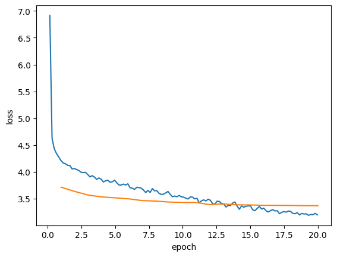

```python
import pandas as pd
import seaborn as sns
import matplotlib.pyplot as plt

train_log = pd.DataFrame({
    'loss': train_loss,
    'epoch': train_epoch
})
test_log = pd.DataFrame({
    'loss': test_loss,
    'epoch': test_epoch
})

sns.lineplot(
    data=train_log,
    x='epoch',
    y='loss'
)
sns.lineplot(
    data=test_log,
    x='epoch',
    y='loss'
)

plt.show()
```

Можно сказать, что модель достигла максимума, так как на валидационном датасете изменений нет, если продолжить обучения есть риск начала переобучения